# Tableaux synthétiques

PP+JLL

11 octobre 2018

# Tableaux synthétiques

## Problématique

Produire des tableaux synthétiques prêts à être diffusés combinant divers types de statistiques sur plusieurs variables croisées. Le modèle implicite de tableau est celui des sorties de la ‘PROC TABULATE’ de SAS.

## Solution retenue

La solution retenue est la fonction `tabular` du package **tables**. Cette fonction est largement inspirée de la ‘PROC TABULATE’ de SAS avec une syntaxe compatible avec R.

```r
library("tables")
```

## Particularités de syntaxe

- La fonction `tabular` utilise le principe des **formules** utilisé en R de base assez systématiquement pour décrire les interactions entre variables. Les **formules** sont également utilisées dans le package **ggformula** mis en avant pour les graphiques. Les fonctions utilisant les **formules** ont la particularité de n’avoir la table de données cible qu’en second paramètre, le premier paramètre étant la formule. Cette particularité provient de la possibilité -qui ne sera pas utilisée ici- de se passer de la mentiòn de la table de données cible en fournissant à l’intérieur de la formule directement des vecteurs R. Malheureusement cela perturbe aussi légèrement l’utilisation du pipe `%>%` pour lequel il faut utiliser une notation un peu plus compliquée.
- Avec `tabular`deux opérateurs jouent un rôle majeur :  
  `+` qui juxtapose plusieurs tableaux de résultats  
  `*` qui permet de croiser des variables (autant qu’on veut jusqu’à ce que la ligne devienne trop longue pour être lisible), ou une variable et les modalités de calcul (fonction statistique, mode de présentation)
- Il existe deux grands types de données : quantitatives et qualitatives. Pour ces dernères, la fonction `tabular`demande impérativement à ce qu’elle soient codées sous forme de facteur (ni nombre, ni chaîne de caractères).  
  Dans l’exemple ci dessous, le sexe est codé numériquement et on cherche à faire une ventilation de la moyenne d’âge et du nombre de personnes par grade selon le sexe. L’appel échoue avec un message peu explicite, mais significatif de l’absence de facteurs là où on devrait en avoir.  
  Il faut également mentionner que les facteurs sont pratiques pour réordonner les modalités.

```r
df <- read.table(text=
"sexe grade age
2     A     40
1     A     50
2     B     20
1     C     30",header=TRUE)
```

```r
df %>% tabular(age*mean + grade ~ sexe,  # La formule : deux tableaux juxtaposés
               .)                        # Pour le pipe : l'endroit où doit "atterrir" le résultat précédent
```

```
## [1] "Duplicate values: age and sexe"
```

Et en convertissant en facteurs :

```r
df1 <- df %>% mutate(sexe=as.factor(sexe))
df1 %>% tabular(age*mean + grade ~ sexe,.)
```

```
##
##             sexe
##             1    2
##  age   mean 40   30
##  grade A     1    1
##        B     0    1
##        C     1    0
```

On peut d’ailleurs aussi en profiter pour associer des libellés plus explicites :

```r
df1 <- df %>% mutate(sexe=factor(sexe,levels=c(1,2),labels=c("Homme","Femme")))
df1 %>% tabular(age*mean + grade ~ sexe,.)
```

```
##
##             sexe
##             Homme Femme
##  age   mean 40    30
##  grade A     1     1
##        B     0     1
##        C     1     0
```

## Exemples

Les exemples qui suivent utilisent une base inspirée du Système d’Information pour les Ressources Humaines, avec des données générées aléatoirement et sur un champ géographique restreint.

```r
library("openxlsx")
base <- read.xlsx("donnees/base light.xlsx")
base %>%
  mutate(Direction=as.factor(affectation)     # Direction d'affectation
    ,Etablissement=as.factor(affectation2)    # Etablissement au sein de la direction d'affectation
             ,sexe=as.factor(sexe)
            ,Grade=as.factor(codhie)          # Grade de l'agent
        ) -> base
```

### Simples comptages par direction et grade, avec sous totaux

On utilise `1` pour indiquer qu’on veut une totalisation (en plus de la ventilation, donc `+`).

```r
base %>% tabular( (Direction+1)~(Grade+1), . )
```

```
##
##                                         Grade
##  Direction                               A+   A  B   C  En All
##  Direction régionale de Antilles-Guyane 30    46  70 41 39 226
##  Direction régionale de Bretagne        25    37  56 14 34 166
##  All                                    55    83 126 55 73 392
```

### Visualiser les résultats avec `View`

Le résultat de `tabular` n’est pas un data frame, mais une structure complexe qui contient tous les éléments de la mise en page du tableau. Néanmoins le package définit une fonction de conversion en matrice de chaînes de caractères qui peut être visualisée ou transformée en data frame, ou les deux :

```r
base %>% tabular( (Direction+1)~(Grade+1), . ) %>%
  as.matrix() %>%
  as.data.frame() -> t1
t1
```

```
##                                       V1    V2 V3  V4 V5 V6  V7
## 1                                        Grade
## 2                              Direction    A+  A   B  C En All
## 3 Direction régionale de Antilles-Guyane    30 46  70 41 39 226
## 4        Direction régionale de Bretagne    25 37  56 14 34 166
## 5                                    All    55 83 126 55 73 392
```

```r
View(t1)
```

### Changer les titres avec `Heading`

```r
base %>% tabular( (Direction+Heading("Total")*1)~(Grade+Heading("Tous")*1), . )
```

```
##
##                                         Grade
##  Direction                               A+   A  B   C  En Tous
##  Direction régionale de Antilles-Guyane 30    46  70 41 39 226
##  Direction régionale de Bretagne        25    37  56 14 34 166
##  Total                                  55    83 126 55 73 392
```

### Intégrer un calcul statistique

Sur le seul champ de la Bretagne, on veut le décompte par sexe et la moyenne d’âge :

```r
base %>%
  filter((substr(identi,1,3)=="R35")&(ligne == "ligne L")) %>%
  tabular( Direction+1 ~ sexe*(1+age*mean)+1,.)
```

```
##
##                                         sexe
##                                         Femme      Homme
##                                               age        age
##  Direction                              All   mean All   mean  All
##  Direction régionale de Antilles-Guyane  0    NaN   0      NaN   0
##  Direction régionale de Bretagne        88     41  78    42.01 166
##  All                                    88     41  78    42.01 166
```

Les parenthèses règlent la distributivité des calculs. L’exemple précédent était constitué du croisement sur deux variables avec une juxtaposition horizontale de tableaux, ci dessous on obtient une simple juxtaposition horizontale de tableaux faits chacun sur une variable.

```r
base %>%
  filter((substr(identi,1,3)=="R35")&(ligne == "ligne L")) %>%
  tabular( Direction+1 ~ sexe +1*(1+age*mean),.)
```

```
##
##                                                     All
##                                         sexe            age
##  Direction                              Femme Homme All mean
##  Direction régionale de Antilles-Guyane  0     0      0   NaN
##  Direction régionale de Bretagne        88    78    166 41.47
##  All                                    88    78    166 41.47
```

### Changer le format des nombres avec `Format`

```r
base %>%
  filter((substr(identi,1,3)=="R35")&(ligne == "ligne L")) %>%
  tabular( Direction+1 ~ sexe*(1+age*mean*Format(digits=0))+1,.)
```

```
##
##                                         sexe
##                                         Femme      Homme
##                                               age        age
##  Direction                              All   mean All   mean All
##  Direction régionale de Antilles-Guyane  0    NaN   0    NaN    0
##  Direction régionale de Bretagne        88     41  78     42  166
##  All                                    88     41  78     42  166
```

### Contrôler les modalités utilisées en ligne et colonne

La fonction `tabular` se sert de la définition des facteurs pour savoir quelles sont les modalités à afficher. Dans le cas précédent, le code Direction correspond à deux directions régionales donc deux modalités, même si on n’en a sélectionné qu’une (celle de Bretagne). Pour éliminer la ligne concernant l’autre direction et pour lesquelles on n’a pas d’observation, il faut transformer le facteur pour qu’il ne contienne plus que les seules modalités vraiment présentes.

```r
base %>%
  filter((substr(identi,1,3)=="R35")&(ligne == "ligne L")) %>%
  mutate(Direction=as.factor(as.character(Direction))) %>%        # Reconstruction du facteur
  tabular( Direction+1 ~ sexe*(1+age*mean*Format(digits=0))+1,.)
```

```
##
##                                  sexe
##                                  Femme      Homme
##                                        age        age
##                                  All   mean All   mean All
##  Direction régionale de Bretagne 88    41   78    42   166
##  All                             88    41   78    42   166
```

### Croiser les modalités en ligne comme en colonne

On peut croiser les variables utilisées pour les ventilations indiféremment en ligne et en colonne. Ci dessous on cherche une ventilation des effectifs totaux par Direction et Etablissement.

```r
base %>%
  filter(ligne == "ligne L") %>%
  tabular( (Direction+1)*(Etablissement+1) ~ 1,.)
```

```
##
##  Direction                              Etablissement                                     All
##  Direction régionale de Antilles-Guyane Direction régionale de Antilles-Guyane Dirag       44
##                                         Direction régionale de Antilles-Guyane Guadeloupe  58
##                                         Direction régionale de Antilles-Guyane Guyane      56
##                                         Direction régionale de Antilles-Guyane Martinique  64
##                                         Direction régionale de Bretagne                     0
##                                         All                                               222
##  Direction régionale de Bretagne        Direction régionale de Antilles-Guyane Dirag        0
##                                         Direction régionale de Antilles-Guyane Guadeloupe   0
##                                         Direction régionale de Antilles-Guyane Guyane       0
##                                         Direction régionale de Antilles-Guyane Martinique   0
##                                         Direction régionale de Bretagne                   166
##                                         All                                               166
##  All                                    Direction régionale de Antilles-Guyane Dirag       44
##                                         Direction régionale de Antilles-Guyane Guadeloupe  58
##                                         Direction régionale de Antilles-Guyane Guyane      56
##                                         Direction régionale de Antilles-Guyane Martinique  64
##                                         Direction régionale de Bretagne                   166
##                                         All                                               388
```

### Retravailler le tableau

Le tableau préédent est plein de lignes superflues car R croise les modalités des deux facteurs sans savoir que certains croisements n’ont pas de sens. Une façon relativement simple de résoudre cette difficulté est de travailler sur le tableau résultat en éliminant les lignes superflues. Celles ci ne sont pas nécessairement repérables par des effectifs à zéro car si on s’interessait à une sous population particulière il pourrait y avoir des établissements où cette population serait absente. On va donc plutôt jouer sur les libellés pour éliminer les lignes superflues en partant de la traduction en data frame du résultat :

```r
base %>%
  filter(ligne == "ligne L") %>%
  tabular( (Direction+1)*(Etablissement+1) ~ 1,.) %>%
  as.matrix() %>% as.data.frame() -> t2

library("zoo")                                        # pour la fonction 'na.locf'
t2 %>%
  mutate(W1=ifelse(V1=="",NA,as.character(V1))) %>%   # Les lignes à blanc dans la colonne Direction deviennent manquantes
  mutate(W1=na.locf(W1,na.rm=FALSE)) %>%              # On remplace les valeurs manquantes par la modalité non manquante précédente
  filter(                                             # On se sert de W1 pour garder :
    is.na(W1)|                                        #    les premières lignes de titre
    (V2=="All")|                                      #    les totaux partiels
    ((V1=="All")&(V2=="All"))|                        #    le total général
    startsWith(as.character(V2),W1)) %>%              #    les établissements dont le nom commence par celui de la Direction
  select(-W1)
```

```
##                                       V1                                                V2  V3
## 1 Direction régionale de Antilles-Guyane      Direction régionale de Antilles-Guyane Dirag  44
## 2                                        Direction régionale de Antilles-Guyane Guadeloupe  58
## 3                                            Direction régionale de Antilles-Guyane Guyane  56
## 4                                        Direction régionale de Antilles-Guyane Martinique  64
## 5                                                                                      All 222
## 6                                                          Direction régionale de Bretagne 166
## 7                                                                                      All 166
## 8                                                                                      All 388
```

### Intégrer des pondérations avec `Arguments`

Certaines fonctions statistiques ont besoin d’arguments complémentaires : la fonction `quantile` ou les fonctions de statistiques pondérées du package ‘Hmisc’. Le passage de ces arguments complémentaires se fait à l’aide du mot clé `Arguments`:

```r
library("Hmisc")
base %>%
  filter(ligne == 'ligne L') %>%
  tabular(Direction~(sexe*age*(wtd.mean*Arguments(w=poids)+wtd.quantile*Arguments(w=poids,p=.25))) ,.)
```

```
##
##                                         sexe
##                                         Femme                 Homme
##                                         age                   age
##  Direction                              wtd.mean wtd.quantile wtd.mean wtd.quantile
##  Direction régionale de Antilles-Guyane 41.15    30.83        40.79    30.54
##  Direction régionale de Bretagne        40.19    30.07        42.70    31.71
```

```r
# A comparer avec (en version non pondérée):
base %>%
  filter(ligne == 'ligne L') %>%
  tabular(Direction~(sexe*age*(    mean                   +    quantile*Arguments(        p=.25))) ,.)
```

```
##
##                                         sexe
##                                         Femme          Homme
##                                         age            age
##  Direction                              mean  quantile mean  quantile
##  Direction régionale de Antilles-Guyane 42.48 31.94    41.92 31.00
##  Direction régionale de Bretagne        41.00 32.41    42.01 31.55
```

### Exporter les résultats

Le passage en mode data frame fournit une première option pour exporter les résultats, par exemple sous un tableur : il suffit d’utiliser une écriture en format XLXS ou ODS.  
Une autre solution consiste à créer un fichier html directement sur les résultats de la fonction `tabular`. L’avantage est alors que le package table offre quelques options permettant d’enjoliver le html produit. Ce dernier est ensuite lisible sous Calc.

```r
table_options(CSS =
"<style>
#ID .center {
  text-align: right;
  background-color: aliceblue;
}
</style>", doCSS = TRUE)
base %>%
  filter(ligne == 'ligne L') %>%
  tabular( Direction+1 ~ sexe*(1+age*mean*Format(digits=0))+1,.) %>%
  html("donnees/tabular1.html")
```

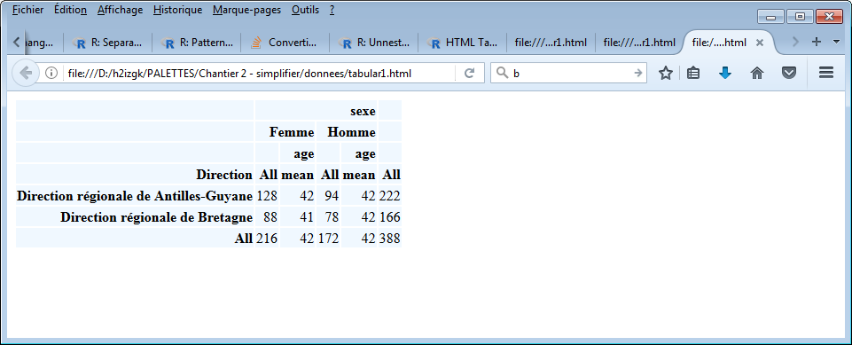

## Solutions viables non retenues

Le package **expss** présente des fonctionnalités similaires à celles de **tables** mais au moyen de fonctions spécialisées et non d’une syntaxe à base de formule. Néanmoins ces fonctions sont assez mal documentées et ne couvrent pas toutes les fonctionnalités de `tabular` en termes de mélanges possibles de statistiques multiples.

## Solutions à ne pas utiliser

Aucune

## Niveau d’intégration à l’USSR

### Développements préconisés

Aucun.

### Points de vigilance

Aucun.

## Intégration au dispositif de formation

Les tableaux synthétiques et la fonction `tabular` sont abordés dans la formation “prise en main rapide de données sous R”.